# CrossYeast GO: an Online Gene Ontology Database Tool

Li Yutze, Yu Zhichao

May 4, 2015

## Introduction

*Gene ontology* is a systematic gene function annotation system, which using a set of distinct and structured terms to describe genes’ entity in three attributes: biological process, molecular function and cellular component. For most model organisms, almost all genes in their genome databases are annotated with a set of GO terms. These annotations come from direct experimental data or are predicted via sequence analysis. GO terms can be used to help analysis gene lists generated by microarries, mass-specs, deep sequencings and genetic screenings, where either simple statistical tests or complex mathematical models are run on these lists, generating a list of over-represented GO terms against the database, which indicates the validity of, or gives extra information to the experiments that generated the gene list. In this course project on biological databases, we are going to build a relational database *CrossYeast GO* on yeast gene ontologies using *MySQL* and *RMySQL* with datasets obtained from the SGD and the Pombase, and using *R-Shiny* to set up an user interface to query the database and execute GO enrichment analysis.

## Motivation

*Schizosaccharomyces pombe* and *Saccharomyces cerevisiae* are two commonly used yeast species in labs. The budding yeast *S. cerevisiae* has an well organized and annotated database, the **SGD** (Saccharomyces Genome Database), while the fission yeast *Sz. pombe* also has the **Pombase** which contains annotations from experimental evidences and some proportion of computational simulations. We are designing to build an gene ontology database that links these two model organisms together using GO terms and gene homology data. Users should be able to query the database using gene lists, generating GO term lists which can fourth used to query, resulting in new gene lists. Also gene lists can be used to find homologues across two yeast species, used in GO query or analysis, then can be used to compare the significances. We also planed to build an io database, allowing users to upload there lists to the server, and other users can query this result database using descriptions the uploader left or gene lists and GO lists to get similar lists, which can be used as references in their experiments.

## Features

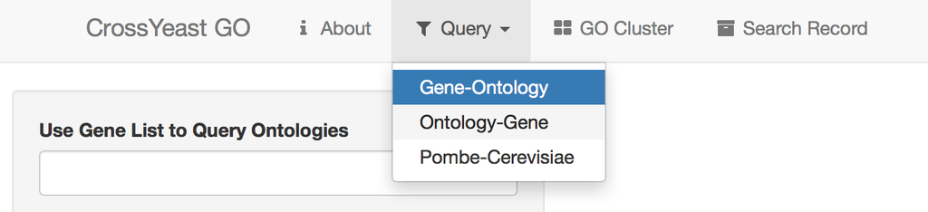

Currently the database system is building in progress:

- Design and set up database structure
- Loading data into database using **R**’s `RMySQL` package
- Design and build the framework of the user interface using **R-Shiny**
- Implement simple query functions
- (Implemented separately) the GO analysis tool

On-the-way functions including:

- Merge the GO analysis tool into the ui
- Uploading results and querying results
- Detail ui improvement using javascript

### Simple Query Operations

#### Query GO using gene lists

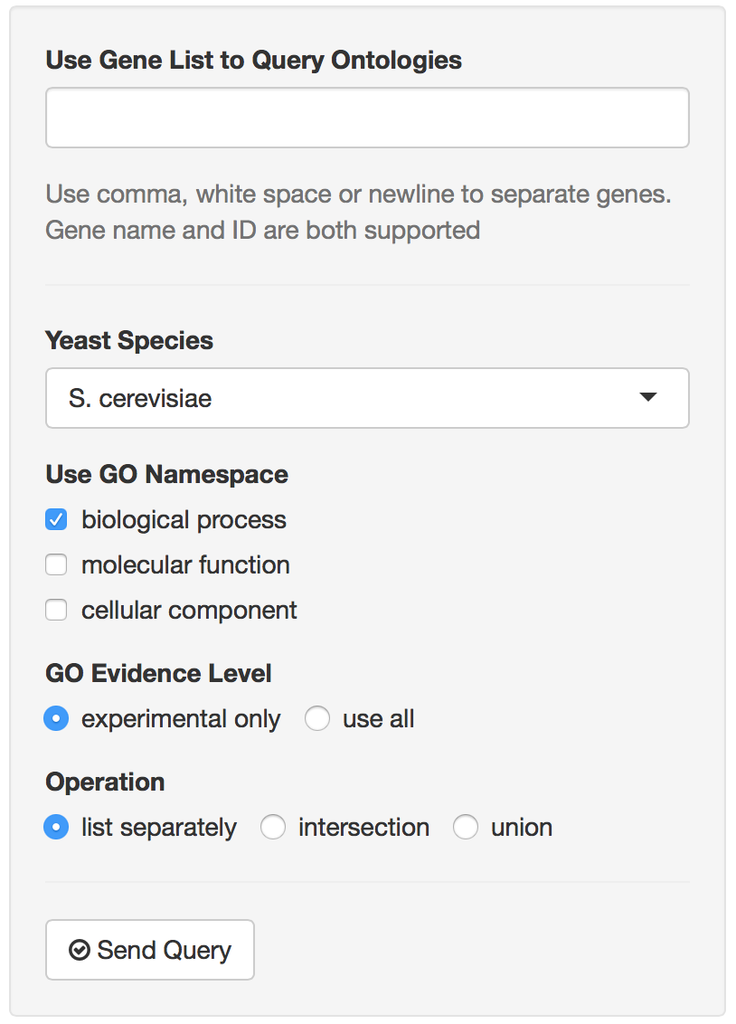

Users can use gene lists containing systematic names or common names separated by comma or white spaces to query the database, generating lists of GO terms. Options including:

- Select yeast species to query (budding and fission yeast)
- Select GO namespaces to query (biological process, molecular function and cellular component)
- Select GO evidence level used to query (experimental or all)
- Select operations for output, including separated lists, intersection and union

#### Query gene using GO lists

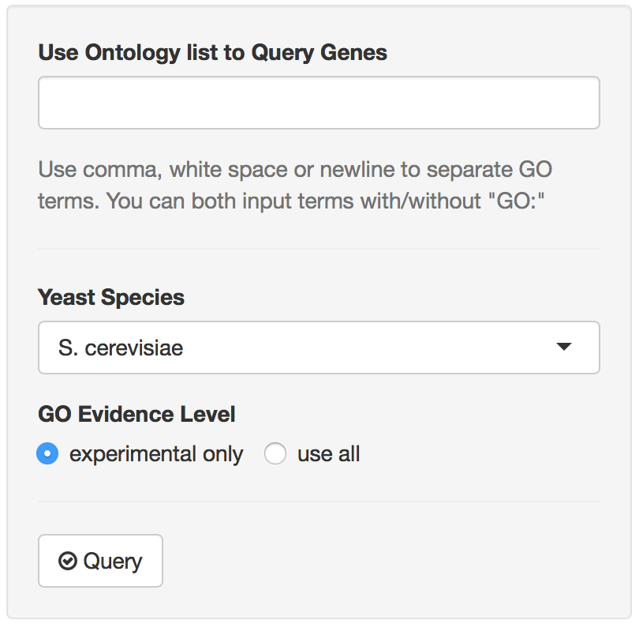

Using a list of GO terms to search against the database genes containing all terms in the list, user can select yeast species and GO evidence level used in query.

#### Query homologous genes cross yeast species

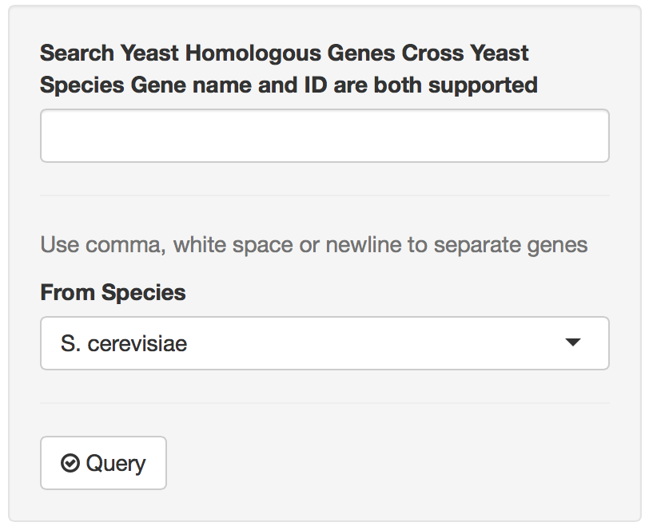

Users can alter the gene list they have here into a list of homolog genes in the other yeast species.

## Database Structure

The database have 9 tables forming 2 parts. The main datasets have 6 tables:

```
s_cerevisiae_desc           : gene information for budding yeast
s_cerevisiae_go             : gene to GO table for budding yeast
sz_pombe_desc               : gene information for fission yeast
sz_pombe_go                 : gene to GO table for fission yeast
go_term_desc                : descriptions on GO terms
yeast_homology              : homology index table linkin two yeasts
```

And a user result part containing 3 tables:

```
user_results                : user result basic information
user_results_genetic        : genetic backgrounds for user's results
user_results_conditional    : environmental backgrounds for user's results
```

The relations among these tables are shown below:

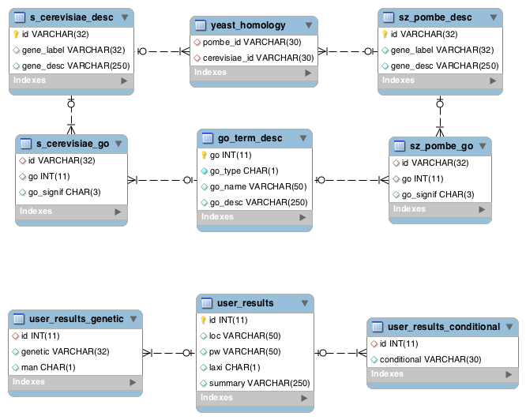